# 市场观察

2016/07/14

## 一、指数估值

### (一)指数动态市盈率

核心指数成分股的动态市盈率中位数走势如下图所示：

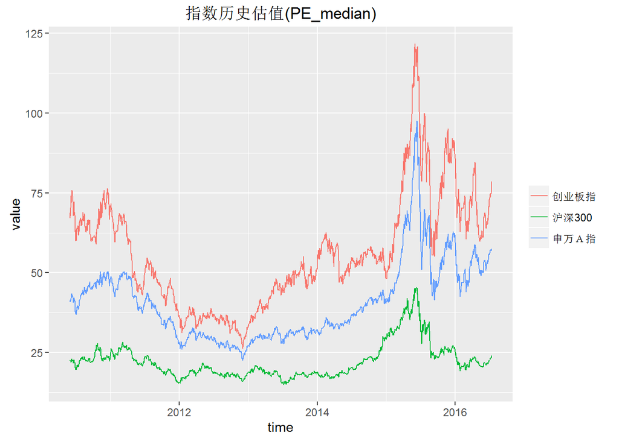

### (二)指数动态市盈率百分位

核心指数上述数据的百分位走势如下图所示：

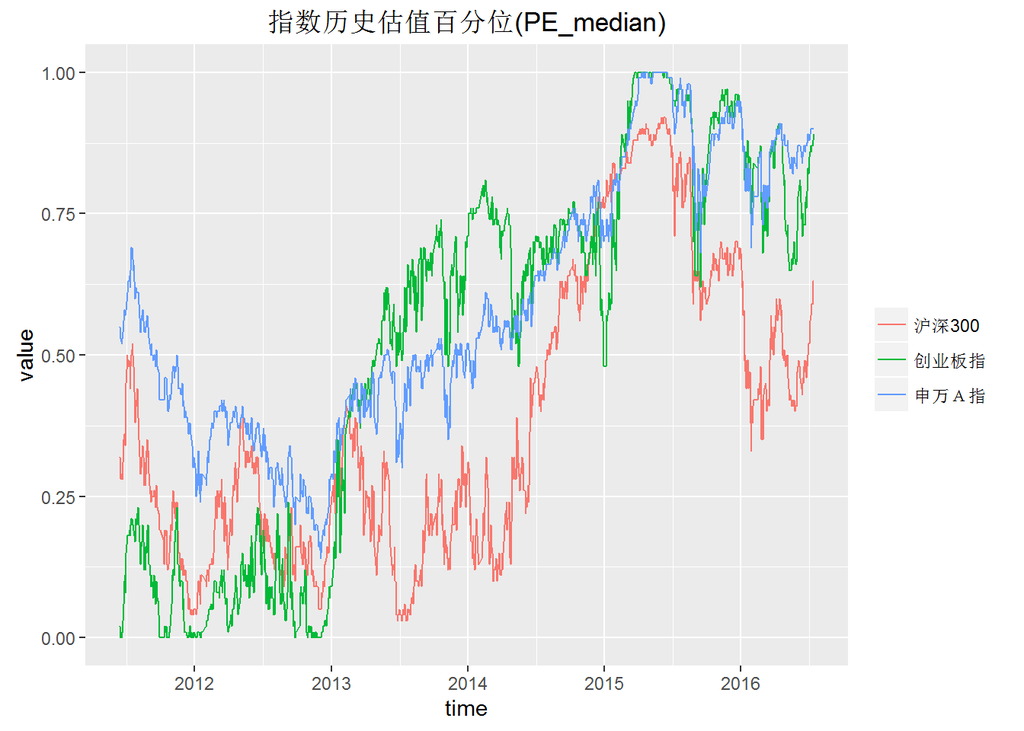

### (三)指数估值概览

纳入观察的18只指数最新的估值情况如下表：

| 日期 | 指数代码 | 指数简称 | 动态市盈率 | 上周动态市盈率 | 市盈率百分位 | 上周市盈率百分位 | 动态市净率 | 市净率百分位 |
| --- | --- | --- | --- | --- | --- | --- | --- | --- |
| 2016-07-13 | EI000979 | 大宗商品 | 50.22 | 46.77 | 0.97 | 0.95 | 2.68 | 0.56 |
| 2016-07-13 | EI000819 | 有色金属 | 69.60 | 65.62 | 0.96 | 0.93 | 4.61 | 0.92 |
| 2016-07-13 | EI801003 | 申万Ａ指 | 57.54 | 57.11 | 0.90 | 0.90 | 4.93 | 0.78 |
| 2016-07-13 | EI000805 | A股资源 | 51.80 | 46.24 | 0.89 | 0.83 | 2.67 | 0.67 |
| 2016-07-13 | EI399006 | 创业板指 | 78.51 | 73.66 | 0.89 | 0.86 | 8.36 | 0.83 |
| 2016-07-13 | EI399959 | 军工指数 | 102.73 | 100.85 | 0.87 | 0.86 | 7.02 | 0.86 |
| 2016-07-13 | EI399005 | 中小板指P | 49.12 | 49.39 | 0.86 | 0.87 | 6.06 | 0.83 |
| 2016-07-13 | EI399330 | 深证100 | 36.86 | 35.51 | 0.83 | 0.79 | 4.49 | 0.75 |
| 2016-07-13 | EI000998 | 中证TMT | 62.42 | 61.06 | 0.82 | 0.80 | 6.28 | 0.79 |
| 2016-07-13 | EI000933 | 中证医药 | 41.20 | 40.02 | 0.76 | 0.71 | 4.85 | 0.52 |
| 2016-07-13 | EI801120 | 申万食品饮料 | 47.22 | 48.27 | 0.74 | 0.76 | 4.72 | 0.65 |
| 2016-07-13 | EI000808 | 医药生物 | 41.65 | 40.79 | 0.73 | 0.66 | 5.61 | 0.72 |
| 2016-07-13 | EI000905 | 中证500 | 41.41 | 40.69 | 0.68 | 0.66 | 3.71 | 0.62 |
| 2016-07-13 | EI000300 | 沪深300 | 23.93 | 23.09 | 0.63 | 0.57 | 2.61 | 0.48 |
| 2016-07-13 | EI000827 | 中证环保 | 39.86 | 37.70 | 0.57 | 0.50 | 4.03 | 0.72 |
| 2016-07-13 | EI000932 | 中证消费 | 34.97 | 35.05 | 0.56 | 0.57 | 4.48 | 0.55 |
| 2016-07-13 | EI000934 | 中证金融 | 16.44 | 15.56 | 0.45 | 0.33 | 2.30 | 0.51 |
| 2016-07-13 | EI000016 | 上证50 | 12.37 | 12.04 | 0.12 | 0.09 | 1.54 | 0.07 |

## 二、基差

### (一)基差走势

三大股指期货隔季合约基差走势如下图：

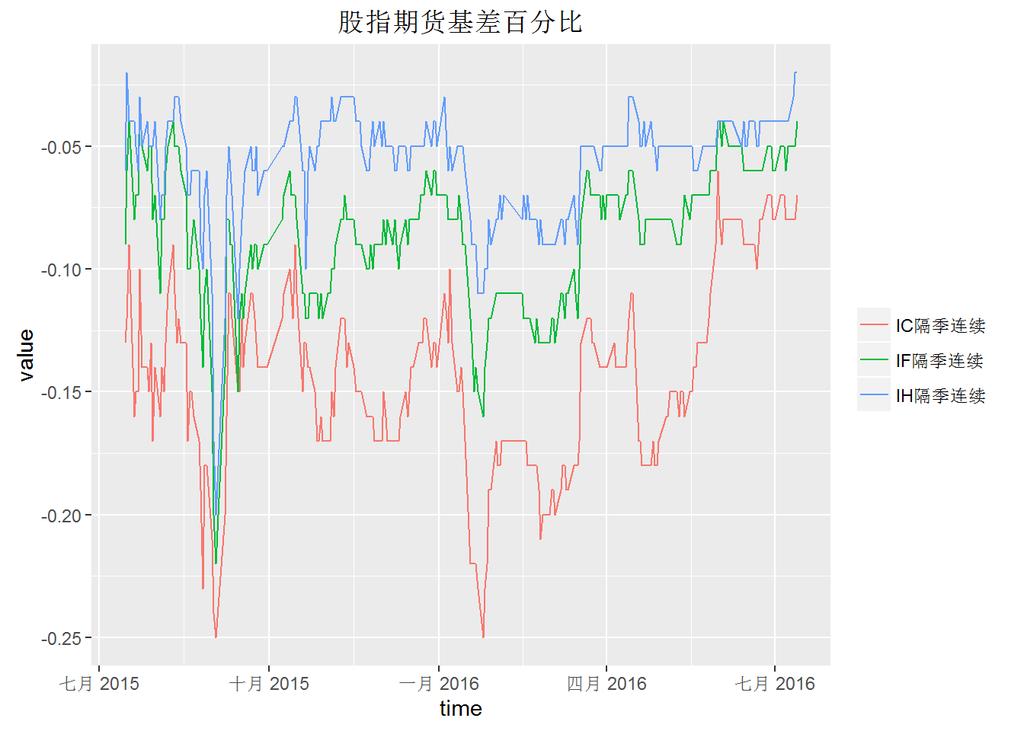

### (二)基差概况

三大股指期货连续合约基差概况如下表：

| 日期 | 合约简称 | 合约收盘价 | 基差 | 基差百分比 | 上周基差 | 上周基差百分比 |
| --- | --- | --- | --- | --- | --- | --- |
| 2016-07-13 | IH当月连续 | 2192.0 | -5.79 | 0.00 | -22.9 | -0.01 |
| 2016-07-13 | IH下月连续 | 2186.6 | -11.19 | -0.01 | -41.1 | -0.02 |
| 2016-07-13 | IH下季连续 | 2174.4 | -23.39 | -0.01 | -56.1 | -0.03 |
| 2016-07-13 | IH隔季连续 | 2143.0 | -54.79 | -0.02 | -87.7 | -0.04 |
| 2016-07-13 | IF当月连续 | 3272.4 | -10.47 | 0.00 | -32.6 | -0.01 |
| 2016-07-13 | IF下月连续 | 3238.8 | -44.07 | -0.01 | -57.4 | -0.02 |
| 2016-07-13 | IF下季连续 | 3210.0 | -72.87 | -0.02 | -111.0 | -0.03 |
| 2016-07-13 | IF隔季连续 | 3138.0 | -144.87 | -0.04 | -174.6 | -0.05 |
| 2016-07-13 | IC当月连续 | 6416.4 | -30.16 | 0.00 | -70.8 | -0.01 |
| 2016-07-13 | IC下月连续 | 6310.2 | -136.36 | -0.02 | -170.8 | -0.03 |
| 2016-07-13 | IC下季连续 | 6211.2 | -235.36 | -0.04 | -269.8 | -0.04 |
| 2016-07-13 | IC隔季连续 | 5963.4 | -483.16 | -0.07 | -467.0 | -0.07 |

## 三、套利

### (一)复牌股票套利

近两天复牌股票套利情况如下表：

[1] “无复牌股票套利”

### (二)定增基金跟踪

截止2016-07-14定增基金数据如下表，明细数据参见钱瀚的模板。

| 代码 | 名称 | 到期日期 | 最新净值 | 昨日收盘价 | 折溢价率 | 整体隐含折价率 | 大盘回撤0.1净值回撤 |
| --- | --- | --- | --- | --- | --- | --- | --- |
| 168101.OF | 九泰锐智 | 20200814 | 1.375 | 1.479 | 0.076 | 0.201 | -0.048 |
| 168102.OF | 九泰锐富 | 20210204 | 1.018 | 1.029 | 0.011 | 0.064 | -0.008 |
| 161222.OF | 国投瑞利 | 20160805 | 1.039 | 1.025 | -0.013 | 0.000 | -0.042 |
| 161225.OF | 国投瑞盈 | 20161119 | 1.013 | 1.020 | 0.007 | 0.063 | -0.073 |
| 501001.OF | 财通精选 | 20170101 | 1.101 | 1.052 | -0.045 | 0.027 | -0.091 |
| 501015.OF | 财通升级 | 20170908 | 1.023 | 1.001 | -0.022 | 0.078 | -0.018 |

定增基金近期的净值走势如下图：

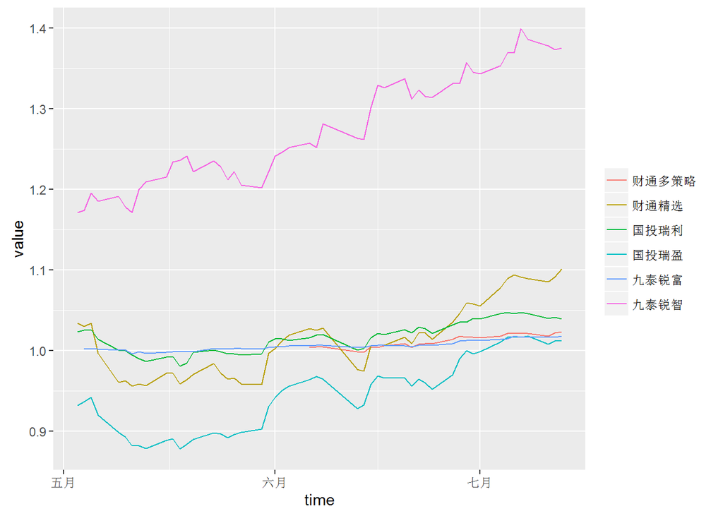

定增基金近期的折溢价走势如下图：

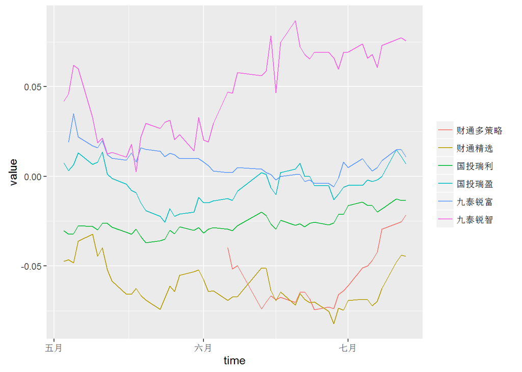

## 四、择时

### (一)大盘均线强弱指数

大盘均线强弱指数在一定程度上可以视为一个反转指标，当大盘均线得分接近8分时，预示市场接近顶部，当大盘均线得分接近0分时，预示市场接近底部。  
大盘均线强弱指数近一年来走势如下图：

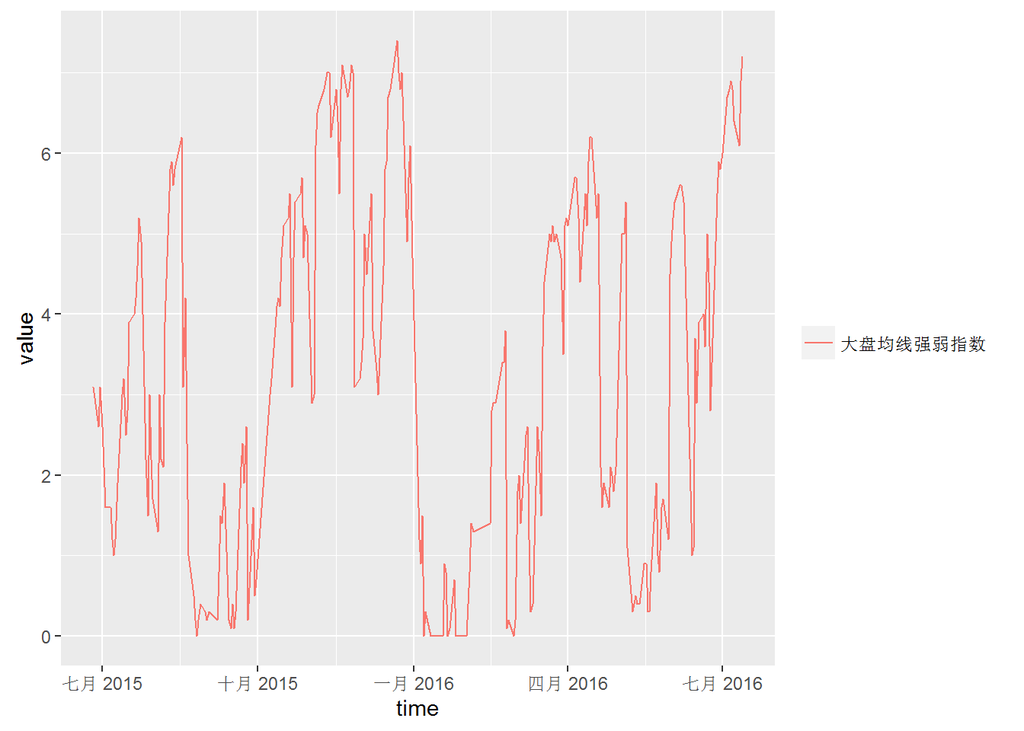

申万一级行业的最新得分及上周得分见下表：

| 日期 | 指数代码 | 指数名称 | 最新值 | 上周值 |
| --- | --- | --- | --- | --- |
| 2016-07-13 | EI801010 | 申万农林牧渔 | 8 | 8 |
| 2016-07-13 | EI801030 | 申万化工 | 8 | 8 |
| 2016-07-13 | EI801050 | 申万有色金属 | 8 | 8 |
| 2016-07-13 | EI801080 | 申万电子 | 8 | 8 |
| 2016-07-13 | EI801110 | 申万家用电器 | 8 | 8 |
| 2016-07-13 | EI801120 | 申万食品饮料 | 8 | 8 |
| 2016-07-13 | EI801130 | 申万纺织服装 | 8 | 7 |
| 2016-07-13 | EI801140 | 申万轻工制造 | 8 | 7 |
| 2016-07-13 | EI801150 | 申万医药生物 | 8 | 7 |
| 2016-07-13 | EI801710 | 申万建筑材料 | 8 | 7 |
| 2016-07-13 | EI801730 | 申万电气设备 | 8 | 8 |
| 2016-07-13 | EI801770 | 申万通信 | 8 | 7 |
| 2016-07-13 | EI801780 | 申万银行 | 8 | 7 |
| 2016-07-13 | EI801790 | 申万非银金融 | 8 | 7 |
| 2016-07-13 | EI801880 | 申万汽车 | 8 | 8 |
| 2016-07-13 | EI801020 | 申万采掘 | 7 | 6 |
| 2016-07-13 | EI801230 | 申万综合 | 7 | 6 |
| 2016-07-13 | EI801720 | 申万建筑装饰 | 7 | 6 |
| 2016-07-13 | EI801740 | 申万国防军工 | 7 | 7 |
| 2016-07-13 | EI801750 | 申万计算机 | 7 | 7 |
| 2016-07-13 | EI801890 | 申万机械设备 | 7 | 7 |
| 2016-07-13 | EI801040 | 申万钢铁 | 6 | 5 |
| 2016-07-13 | EI801160 | 申万公用事业 | 6 | 6 |
| 2016-07-13 | EI801170 | 申万交通运输 | 6 | 6 |
| 2016-07-13 | EI801200 | 申万商业贸易 | 6 | 6 |
| 2016-07-13 | EI801210 | 申万休闲服务 | 6 | 6 |
| 2016-07-13 | EI801760 | 申万传媒 | 6 | 6 |
| 2016-07-13 | EI801180 | 申万房地产 | 5 | 5 |

### (二)LLT及均线择时

LLT本质上是一个改进的单均线择时指标，较原始的均线择时延迟更低。  
择时模型和指数本身的净值走势如下图：

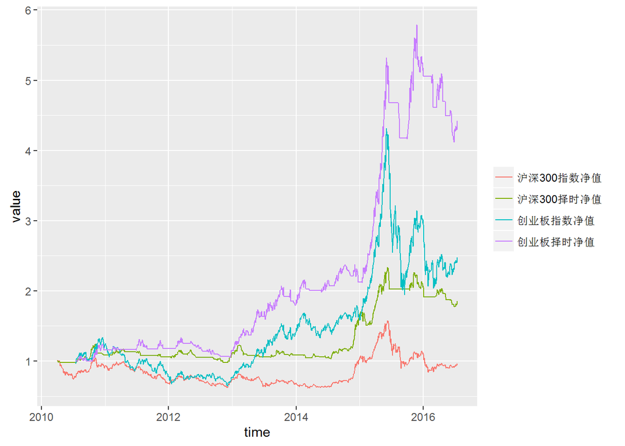

择时模型和指数的收益率统计如下表：

|  | 沪深300指 | 沪深300LLT | 创业板指 | 创业板MA |
| --- | --- | --- | --- | --- |
| 年化收益率 | -0.5 | 10.7 | 17.0 | 29.3 |
| 年化波动率 | 25.9 | 16.5 | 34.8 | 24.0 |
| 年化Sharpe值 | -2.1 | 65.2 | 48.8 | 122.0 |
| 最大回撤 | 46.7 | 24.0 | 54.9 | 28.9 |

择时模型最近10个交易日的信号如下表：

| 日期 | 沪深300收盘价 | 沪深300择时信号 | 创业板收盘价 | 创业板择时信号 |
| --- | --- | --- | --- | --- |
| 2016-06-30 | 3153.921 | hold | 2227.790 | hold |
| 2016-07-01 | 3154.200 | hold | 2211.177 | hold |
| 2016-07-04 | 3204.696 | hold | 2248.712 | hold |
| 2016-07-05 | 3207.383 | hold | 2246.024 | hold |
| 2016-07-06 | 3216.803 | hold | 2241.560 | hold |
| 2016-07-07 | 3209.954 | hold | 2233.922 | hold |
| 2016-07-08 | 3192.280 | hold | 2239.002 | hold |
| 2016-07-11 | 3203.330 | hold | 2218.588 | hold |
| 2016-07-12 | 3273.182 | hold | 2247.354 | hold |
| 2016-07-13 | 3282.868 | hold | 2285.369 | hold |

### (三)网格交易

在经历了三轮股灾，A股逐步回归正常，在过去的一段时间呈现一个震荡的格局，如果未来没有增量信息，很可能维持震荡。结合股指期货的贴水，前期研究了一下网格交易。网格交易的结果如下图：

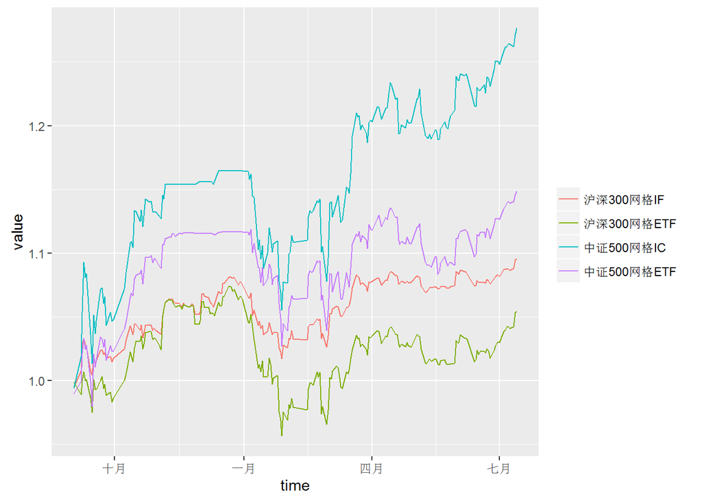

网格交易的收益统计如下表：

|  | 沪深300指数 | 沪深300网格IF | 沪深300网格ETF | 中证500指数 | 中证500网格IC | 中证500网格ETF |
| --- | --- | --- | --- | --- | --- | --- |
| 年化收益率 | -2.8 | 11.7 | 6.6 | 5.4 | 34.2 | 18.2 |
| 年化波动率 | 28.6 | 8.2 | 12.4 | 38.7 | 17.8 | 14.2 |
| 年化Sharpe值 | -9.9 | 142.9 | 53.3 | 14.1 | 192.8 | 128.5 |
| 最大回撤 | 26.4 | 5.9 | 10.9 | 33.5 | 9.4 | 8.2 |